# Data Science Capstone Project - Milestone Report

### Background and Objectives

The final outcome of this project will be an app developed in Shiny that demonstrates a predictive keyboard able to predict the next word of a sentence. The objectives of this milestone report are to:

- Demonstrate that the data has been succesfully downloaded and imported into R
- Produce some summary statistics, plots and tables on the imported files
- Document the steps taken to sample the data and clean the file
- Understand the frequency of words and word pairs and the associations between words in the files
- Discuss initial plans for the development of the predictive algorithm

### Data Processing

Three separate data files were provided in order to develop the predictive model. These included text from Twitter, Blogs and Newsfeeds. The data were downloaded and unzipped from the following location https://d396qusza40orc.cloudfront.net/dsscapstone/dataset/Coursera-SwiftKey.zip).

Since the datasets are very large each one was read in chunks by embedding the readLines function into a for loop. The following code illustrates how this was accomplished on the Twitter dataset:

```r
# set the connection and read the first 100 lines
con <- file("en_US.twitter.txt", "r")
nrows <- 100
twitter_data <- readLines(con, nrows)

# loop over the data reading 100 lines at a time up to 4,000,000 records
for(i in 1:40000) {
  next_lines <- readLines(con,nrows,ok = T)
  twitter_data <- c(twitter_data,next_lines)
}
close(con)
```

The following basic summaries were then calculated on the downloaded data:

1. The distribution of the number of words in each file
2. The total number of observations in each file
3. The distribution of the number of characters in each line of the files
4. The size of each of the files

The plots below visualize these summary statistics:

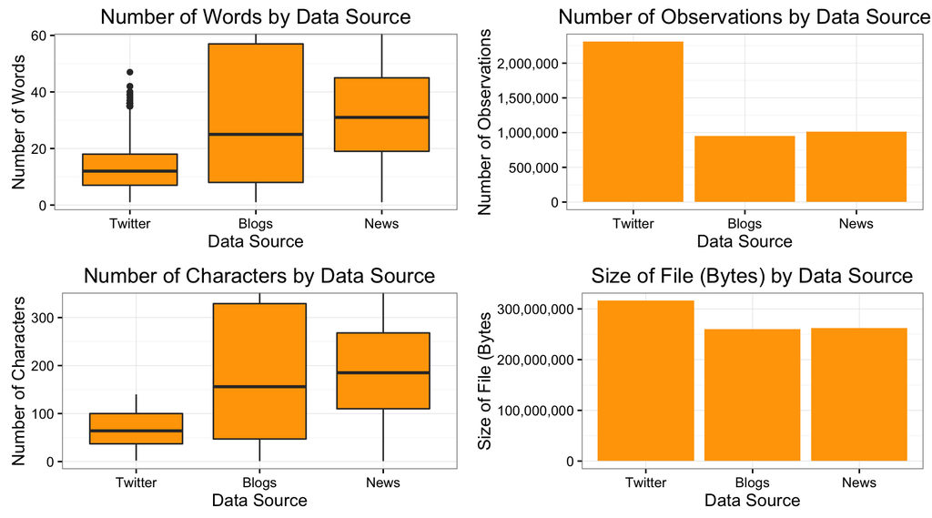

The plots illustrate that:

- The number of observations in the Twitter dataset was significantly larger than the Blogs and Newsfeeds but the average number of words and characters was significantly smaller (as would be expected)
- The average number of words in characters in the Blogs and Newsfeeds was similar but the distribution is much larger for Blogs

### Data Sampling and Cleaning

As the dataset is very large a 1% sample was taken for the exploratory analysis and developement of the predictive algorithm. The code below shows how the three sources of data were set together and the sample was taken:

```r
# set the documents together
all_text_vector <- c(twitter_data,news_data,blogs_data)
rm(list = c("twitter_data","news_data","blogs_data"))

# take a 1% sample of the data to write and test the code
text_sample <- sample(all_text_vector, length(all_text_vector)*0.01, replace = FALSE)
```

In order to explore the data and build the algorithm the following data cleansing steps were taken:

1. Make all text lower case
2. Remove colons, hypens, numbers and all other punctuation
3. Removing profanity (NOTE: The list of profanity was sourced from the following website http://fffff.at/googles-official-list-of-bad-words/
4. Stripped white-space

Although stemming and removing stop words is common in text mining tasks since the objective of this algorithm was ‘next word’ predicting these cleaning steps were not appropriate.

### Frequency of terms

The following analysis aims to understand the frequency of words and word pairs in the sample file. The report will show the top uni-grams (single terms), bi-grams (pairs of terms) and tri-grams (triplets of terms).

#### Uni-grams

```r
library(tm)

# create the document term matrix - limit the maximum word length to 40 and remove very sparse terms
sample_dtm <- removeSparseTerms(DocumentTermMatrix(corpus_sample_text,
                                                   control = list(wordLengths = c(1,40))),0.9999)

# look at some examples
inspect(sample_dtm[1:10,1:10])
```

```
## <<DocumentTermMatrix (documents: 10, terms: 10)>>
## Non-/sparse entries: 0/100
## Sparsity           : 100%
## Maximal term length: 5
## Weighting          : term frequency (tf)
##
##     Terms
## Docs \u0097 \u0095 \u0096 ½ a aa aaa aam aaron ab
##   1       0      0      0 0 0  0   0   0     0  0
##   2       0      0      0 0 0  0   0   0     0  0
##   3       0      0      0 0 0  0   0   0     0  0
##   4       0      0      0 0 0  0   0   0     0  0
##   5       0      0      0 0 0  0   0   0     0  0
##   6       0      0      0 0 0  0   0   0     0  0
##   7       0      0      0 0 0  0   0   0     0  0
##   8       0      0      0 0 0  0   0   0     0  0
##   9       0      0      0 0 0  0   0   0     0  0
##   10      0      0      0 0 0  0   0   0     0  0
```

NOTE: Removing the sparse terms removed 83,312 (8%) of the terms

The table below shows the top 20 terms and their frequencies:

```
##      term_frequency term
## the           47701  the
## to            27543   to
## and           24196  and
## a             23660    a
## of            20101   of
## i             16582    i
## in            16512   in
## for           11128  for
## is            10731   is
## that          10225 that
## you            9594  you
## it             9191   it
## on             8175   on
## with           7074 with
## was            6354  was
## my             6023   my
## at             5776   at
## be             5518   be
## this           5404 this
## have           5285 have
```

Based on the cleaned sample with the sparse terms removed 105 terms cover 50% of the words in the files and 3,602 terms cover 90% of the words in the files.

The Wordcloud below visualizes the freqency of the uni-grams in the sample file:

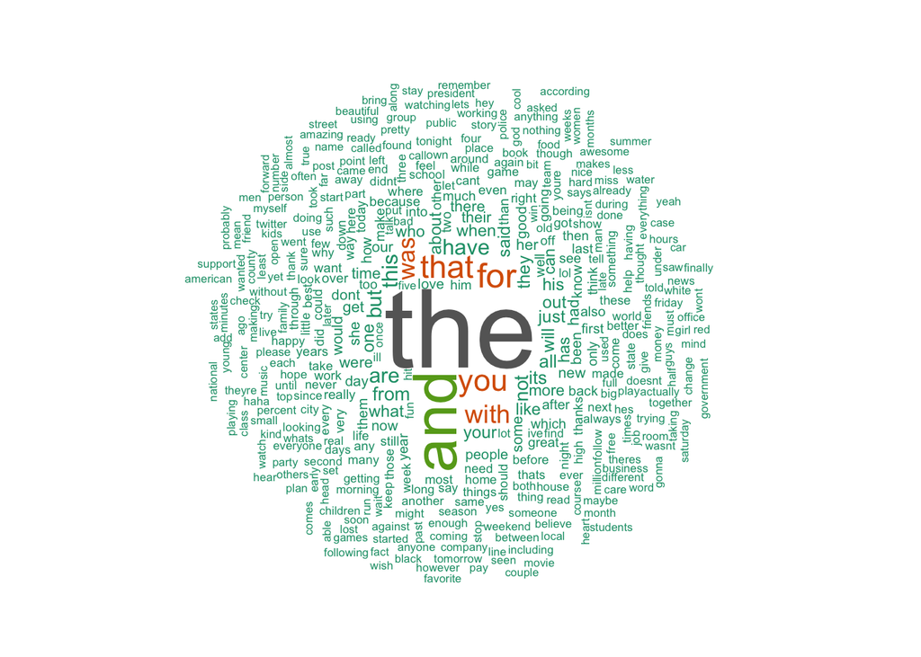

#### Bi-grams

The following code was used to remove sparse terms, generate bi-grams and show a sample of the output:

```r
library(tm)

BigramTokenizer <-
  function(x)
    unlist(lapply(ngrams(words(x), 2), paste, collapse = " "), use.names = FALSE)

sample_text_bigram <- TermDocumentMatrix(corpus_sample_text, control = list(tokenize = BigramTokenizer))
inspect(removeSparseTerms(sample_text_bigram[1:10, 1:10], 0.99))
```

```
## <<TermDocumentMatrix (terms: 0, documents: 10)>>
## Non-/sparse entries: 0/0
## Sparsity           : 100%
## Maximal term length: 0
## Weighting          : term frequency (tf)
##
##       Docs
## Terms  1 2 3 4 5 6 7 8 9 10
```

```r
sample_text_bigram <- removeSparseTerms(sample_text_bigram, 0.99)
```

The table below shows the frequency counts of the top 20 bi-grams:

```
##          bigram_term term_frequency
## of the        of the           4339
## in the        in the           4042
## to the        to the           2145
## for the      for the           2024
## on the        on the           1880
## to be          to be           1602
## at the        at the           1445
## in a            in a           1217
## and the      and the           1193
## with the    with the           1082
## is a            is a            993
## it was        it was            953
## i was          i was            911
## for a          for a            901
## i have        i have            869
## from the    from the            858
## it is          it is            844
## and i          and i            842
## will be      will be            837
## with a        with a            822
```

The Wordcloud below visualizes the freqency of the bi-grams in the sample file:

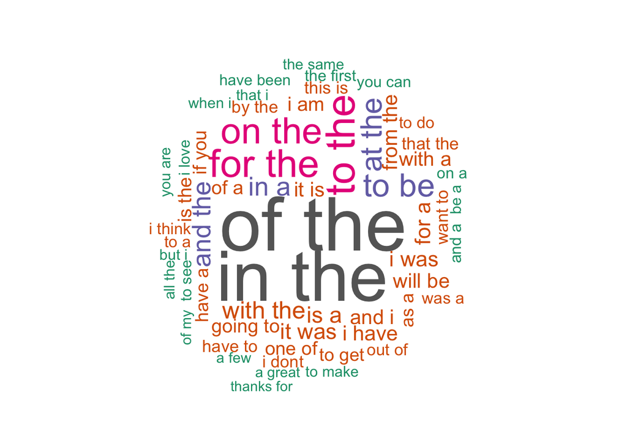

#### Tri-grams

The following code was used to remove sparse terms, generate tri-grams and show a sample of the output:

```r
library(tm)

TrigramTokenizer <-
  function(x)
    unlist(lapply(ngrams(words(x), 3), paste, collapse = " "), use.names = FALSE)

sample_text_trigram <- TermDocumentMatrix(corpus_sample_text, control = list(tokenize = TrigramTokenizer))
inspect(removeSparseTerms(sample_text_trigram[1:10, 1:10], 0.999))
```

```
## <<TermDocumentMatrix (terms: 0, documents: 10)>>
## Non-/sparse entries: 0/0
## Sparsity           : 100%
## Maximal term length: 0
## Weighting          : term frequency (tf)
##
##       Docs
## Terms  1 2 3 4 5 6 7 8 9 10
```

```r
sample_text_trigram <- removeSparseTerms(sample_text_trigram, 0.999)
```

The table below shows the frequency counts of the top 20 tri-grams:

```
##                  trigram_term term_frequency
## one of the         one of the            355
## a lot of             a lot of            268
## thanks for the thanks for the            209
## to be a               to be a            192
## going to be       going to be            185
## out of the         out of the            152
## i want to           i want to            148
## the end of         the end of            148
## some of the       some of the            143
## it was a             it was a            135
## as well as         as well as            129
## part of the       part of the            124
## i dont know       i dont know            122
## be able to         be able to            118
## thank you for   thank you for            115
## the rest of       the rest of            112
## this is a           this is a            111
## a couple of       a couple of            109
## i have a             i have a            108
## i have to           i have to            108
```

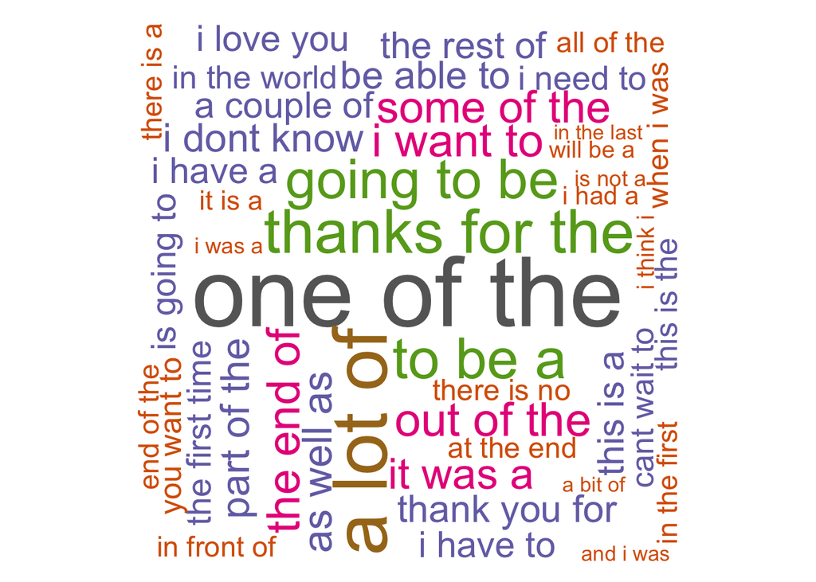

### Thoughts on Model Development

The n-gram frequencies created as part of this exploratory analysis provide a good foundation for predictive model development. Initially, a very simple model will be developed by creating probability lookup tables based on these n-grams.

The following are additional considerations for the development of the algorithm:

1. **Reducing the number of terms in the model to make the prediction more efficient:** Only the most frequent terms will be kept in the predictive model, synonyms and common misspellings will also be considered to reduce the number of terms further
2. **Evaluating the number of n-grams required:** Understanding the efficiency trade-off between using more n-grams, the predictive accuracy and the runtime
3. **Smoothing the probabilities:** Ensuring that all n-grams have a non-zero probability
4. **Evaluating the ‘success’ of the prediction:** Designing a methodology for measuring the ‘success’ of the algorithm e.g. the % of times the algorithm can correctly predict the next word based on the first 1,2,3…words
5. **Predicting the next word probability based on unobserved n-grams:** The algorithm will have to predict the next word based on some unobserved n-grams. As recommended I will investigate the use of backoff models in order to handle these scenarios